# 이탈률

올림푸스

2020-04-24

# 일반 고객

## 이탈율 계산을 위한 data frame 구성

```r
colnames(normal_client)
```

[1] “CLNT_ID” “CLNT_GEN” “CLNT_AGE” “HIT_AVG” “PAG_VIEW_AVG” [6] “SESS_CT” “CLNT_BUY_CT” “CLNT_BUY_TOT” “전자제품” “리빙”  
[11] “식품” “스포츠” “패션” “뷰티” “유아용품”  
[16] “취미용품” “사무용품” “상품권” “C1_CT” “C2_CT”  
[21] “C3_CT” “C4_CT” “C5_CT” “C6_CT” “C7_CT”  
[26] “C8_CT” “C9_CT” “C10_CT” “CLNT_CL” “Cluster_num”

```r
normal <- normal_client[c(1,29,30)]
# CLNT_ID, CLNT_CL, Cluster_num

session <- train_session
session$SESS_DT <- as.Date(session$SESS_DT, tz = '', tryFormats = c('%Y%m%d', '%Y-%m-%d'))

normalsess <- inner_join(normal, session, by='CLNT_ID')
# normal client들의 session 정보만 따로 담기

dfnor <- normalsess %>%  distinct(CLNT_ID, SESS_DT) %>%  arrange(CLNT_ID, SESS_DT)
# 동일 일자에 생성한 세션 정보 제거

dfnor <- dfnor %>% group_by(CLNT_ID) %>% mutate(cnt = n())
# clnt_id 당 총 구매 일자 수 구하기

dfnor <-dfnor[order(dfnor$CLNT_ID, dfnor$SESS_DT),]
# clnt_id와 sess_dt로 정렬하기

dfnor$SESS_DTlag<-
  shift(dfnor$SESS_DT, n=1, fill=NA, type = "lag")
dfnor$SESS_DTdiff<-dfnor$SESS_DT - dfnor$SESS_DTlag
# SESS_DTlag 열에 앞 행에 있는 SESS_DT를 저장
# 앞 행에 있는 SESS_DT와의 간격을 계산

dfnor$SESS_DTfinal<-ifelse(dfnor$CLNT_ID == shift(dfnor$CLNT_ID, n=1, fill = NA, type = "lag"),
                        # TRUE: 앞 행의 CLNT_ID와 일치하면(동일 CLNT_ID의 구매일자가 맞으면)
                        dfnor$SESS_DT - shift(dfnor$SESS_DT, n=1, fill=NA, type = "lag"),
                        # FALSE: clnt_id가 한 행밖에 없을 때
                        NA)
```

## 결측치 처리

```r
b <-dfnor %>% filter(cnt==1)
b$SESS_DTfinal <- 147
b$mean_term <- 147
b <- b[c(1,3,7)]
# 구매 일자가 하루 뿐인 경우
# 즉, 평균 구매 주기를 구할 수 없는 경우
# 2018/04/01~2018/08/25 총 147일을 구매 주기로 넣음
```

## 평균 구매 주기 구하기

```r
a <- dfnor %>% filter(cnt >= 2)
a <- na.omit(a)
# 구매 일자가 2일 이상
# 즉, 평균 구매 주기를 구할 수 있는 경우
finalnor_df <- a %>% group_by(CLNT_ID) %>% mutate(mean_term =round(mean(SESS_DTfinal))) %>% select(CLNT_ID,cnt,mean_term) %>%  distinct(CLNT_ID,cnt,mean_term)
finalnor_df <- rbind(finalnor_df,b)
# a, b를 finalnor_df로 합쳐줌
```

## 최종 구매 경과일 구하기

```r
dfnor<- dfnor %>% group_by(CLNT_ID) %>% mutate(last_day = max(SESS_DT))
lastnor <- dfnor %>% distinct(CLNT_ID, last_day)
# 마지막 구매 일자를 구함

finalnor_df <- inner_join(finalnor_df, lastnor, by='CLNT_ID')
finalnor_df$finalterm <- as.numeric(as.Date('2018-08-25') - finalnor_df$last_day)
# 마지막 구매 일자로 부터 2018년 8월 25일까지의 간격을 구함

finalnor_df$riskratio <- finalnor_df$finalterm/finalnor_df$mean_term
# riskratio=finalterm/mean_term
```

## 이탈 기준 정하기

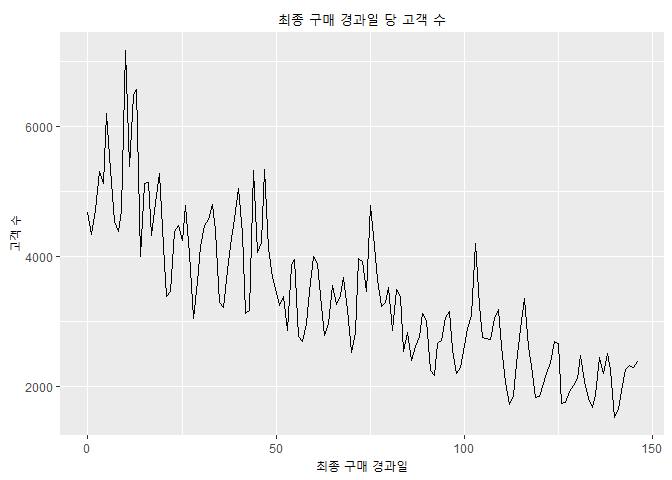

```r
aa <- finalnor_df %>% group_by(finalterm) %>% summarise(n=n())

# finalterm의 분포를 확인
ggplot(data=aa,aes(x=finalterm,y=n)) +
  geom_line() +
  ggtitle('최종 구매 경과일 당 고객 수') +
  xlab('최종 구매 경과일') +
  ylab('고객 수')+
  theme(plot.title = element_text(hjust=.5))
```

```r
finalnor_df$churn <- ifelse(finalnor_df$finalterm>=53, 1, 0)
```

기울기가 완만해지기 시작하는 53을 이탈 기준으로 정함

즉, 최종 구매 경과일이 53보다 크거나 같으면 이탈했다고 정의

## Logistic Regression 수행

```r
fitnor <- glm(churn ~ riskratio, data = finalnor_df, family = binomial())
summary(fitnor)
```

Call: glm(formula = churn ~ riskratio, family = binomial(), data = finalnor_df)

Deviance Residuals: Min 1Q Median 3Q Max  
-3.2392 -1.1072 0.0975 1.2225 1.2480

Coefficients: Estimate Std. Error z value Pr(>|z|)  
(Intercept) -0.2022393 0.0033281 -60.77 <0.0000000000000002 *riskratio 0.1046793 0.0008401 124.61 <0.0000000000000002* — Signif. codes: 0 ‘**’ 0.001 ’**’ 0.01 ’’ 0.05 ‘.’ 0.1 ’ ’ 1

(Dispersion parameter for binomial family taken to be 1)

```
Null deviance: 687485  on 496636  degrees of freedom
```

Residual deviance: 646214 on 496635 degrees of freedom AIC: 646218

Number of Fisher Scoring iterations: 6

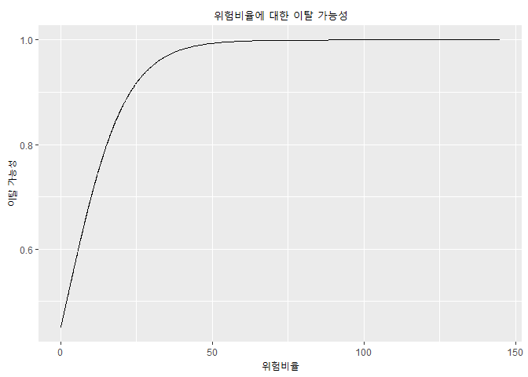

```r
finalnor_df$y <- exp(-0.2022393+0.1046793*finalnor_df$riskratio)/(1+exp(-0.2022393+0.1046793*finalnor_df$riskratio))

ggplot(data=finalnor_df, aes(x=riskratio, y=y)) +
  geom_line() +
  ggtitle('위험비율에 대한 이탈 가능성') +
  xlab('위험비율') +
  ylab('이탈 가능성') +
  theme(plot.title = element_text(hjust=.5))
```

## 분류 예측 수행

```r
probnor <- predict(fitnor, newdata=finalnor_df, type='response')
prednor <- ifelse(probnor > .5, '이탈', '잔여')
prednor <- factor(prednor, levels=c('이탈', '잔여'), labels = c('이탈', '잔여'))
logit.prefnor <- table(finalnor_df$churn, prednor, dnn=c('actual', 'predict'))
```

## 예측 정확도

```r
( accnor <- (sum(logit.prefnor) - sum(diag(logit.prefnor))) / sum(logit.prefnor) )
```

[1] 0.6095277

# VIP 고객

## 이탈율 계산을 위한 data frame 구성

```r
colnames(vip_client)
```

[1] “CLNT_ID” “CLNT_GEN” “CLNT_AGE” “HIT_AVG” “PAG_VIEW_AVG” [6] “SESS_CT” “CLNT_BUY_CT” “CLNT_BUY_TOT” “전자제품” “리빙”  
[11] “식품” “스포츠” “패션” “뷰티” “유아용품”  
[16] “취미용품” “사무용품” “상품권” “C1_CT” “C2_CT”  
[21] “C3_CT” “C4_CT” “C5_CT” “C6_CT” “C7_CT”  
[26] “C8_CT” “C9_CT” “C10_CT” “CLNT_CL” “Cluster_num”

```r
vip <- vip_client[c(1,29,30)]
# CLNT_ID, CLNT_CL, Cluster_num

session <- train_session
session$SESS_DT <- as.Date(session$SESS_DT, tz = '', tryFormats = c('%Y%m%d', '%Y-%m-%d'))

vipsess <- inner_join(vip, session, by='CLNT_ID')
# vip client들의 session 정보만 따로 담기

dfvip <- vipsess %>%  distinct(CLNT_ID, SESS_DT) %>%  arrange(CLNT_ID, SESS_DT)
# 동일 일자에 생성한 세션 정보 제거

dfvip <- dfvip %>% group_by(CLNT_ID) %>% mutate(cnt = n())
# clnt_id 당 총 구매 일자 수 구하기

dfvip <-dfvip[order(dfvip$CLNT_ID, dfvip$SESS_DT),]
# clnt_id와 sess_dt로 정렬하기

dfvip$SESS_DTlag<-
  shift(dfvip$SESS_DT, n=1, fill=NA, type = "lag")
dfvip$SESS_DTdiff<-dfvip$SESS_DT - dfvip$SESS_DTlag
# SESS_DTlag 열에 앞 행에 있는 SESS_DT를 저장
# 앞 행에 있는 SESS_DT와의 간격을 계산

dfvip$SESS_DTfinal<-ifelse(dfvip$CLNT_ID == shift(dfvip$CLNT_ID, n=1, fill = NA, type = "lag"),
                           # TRUE: 앞 행의 CLNT_ID와 일치하면(동일 CLNT_ID의 구매일자가 맞으면)
                           dfvip$SESS_DT - shift(dfvip$SESS_DT, n=1, fill=NA, type = "lag"),
                           # FALSE: clnt_id가 한 행밖에 없을 때
                           NA)
```

## 결측치 처리

```r
d <-dfvip %>% filter(cnt==1)
d$SESS_DTfinal <- 147
d$mean_term <- 147
d <- d[c(1,3,7)]
# 구매 일자가 하루 뿐인 경우
# 즉, 평균 구매 주기를 구할 수 없는 경우
# 2018/04/01~2018/08/25 총 147일을 구매 주기로 넣음
```

## 평균 구매 주기 구하기

```r
c <- dfvip %>% filter(cnt >= 2)
c <- na.omit(c)
# 구매 일자가 2일 이상
# 즉, 평균 구매 주기를 구할 수 있는 경우
finalvip_df <- c %>% group_by(CLNT_ID) %>% mutate(mean_term =round(mean(SESS_DTfinal))) %>% select(CLNT_ID,cnt,mean_term) %>%  distinct(CLNT_ID,cnt,mean_term)
finalvip_df <- rbind(finalvip_df,d)
# c, d를 finalvip_df로 합쳐줌
```

## 최종 구매 경과일 구하기

```r
dfvip<- dfvip %>% group_by(CLNT_ID) %>% mutate(last_day = max(SESS_DT))
lastvip <- dfvip %>% distinct(CLNT_ID, last_day)
# 마지막 구매 일자를 구함

finalvip_df <- inner_join(finalvip_df, lastvip, by='CLNT_ID')
finalvip_df$finalterm <- as.numeric(as.Date('2018-08-25') - finalvip_df$last_day)
# 마지막 구매 일자로 부터 2018년 8월 25일까지의 간격을 구함

finalvip_df$riskratio <- finalvip_df$finalterm/finalvip_df$mean_term
# riskratio=finalterm/mean_term
```

## 이탈 기준 정하기

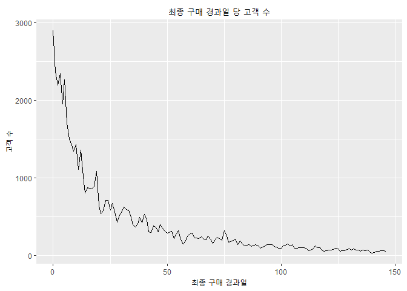

```r
bb <- finalvip_df %>% group_by(finalterm) %>% summarise(n=n())

ggplot(data=bb,aes(x=finalterm,y=n)) +
  geom_line() +
  ggtitle('최종 구매 경과일 당 고객 수') +
  xlab('최종 구매 경과일') +
  ylab('고객 수')+
  theme(plot.title = element_text(hjust=.5))
```

```r
finalvip_df$churn <- ifelse(finalvip_df$finalterm>=21, 1, 0)
```

기울기가 완만해지기 시작하는 21을 이탈 기준으로 정함

즉, 최종 구매 경과일이 21보다 크거나 같으면 이탈했다고 정의

## Logistic Regression 수행

```r
fitvip <- glm(churn ~ riskratio, data = finalvip_df, family = binomial())
summary(fitvip)
```

Call: glm(formula = churn ~ riskratio, family = binomial(), data = finalvip_df)

Deviance Residuals: Min 1Q Median 3Q Max  
-5.8741 -0.7338 -0.5749 0.6913 1.8805

Coefficients: Estimate Std. Error z value Pr(>|z|)  
(Intercept) -1.716473 0.016133 -106.4 <0.0000000000000002 *riskratio 0.948451 0.009688 97.9 <0.0000000000000002* — Signif. codes: 0 ‘**’ 0.001 ’**’ 0.01 ’’ 0.05 ‘.’ 0.1 ’ ’ 1

(Dispersion parameter for binomial family taken to be 1)

```
Null deviance: 81192  on 58698  degrees of freedom
```

Residual deviance: 54939 on 58697 degrees of freedom AIC: 54943

Number of Fisher Scoring iterations: 8

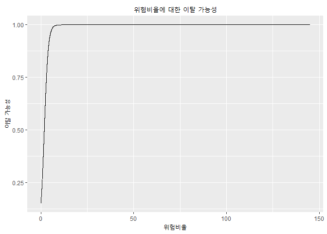

```r
finalvip_df$y <- exp(-1.716473+0.948451*finalvip_df$riskratio)/(1+exp(-1.716473+0.948451*finalvip_df$riskratio))

ggplot(data=finalvip_df, aes(x=riskratio, y=y)) +
  geom_line() +
  ggtitle('위험비율에 대한 이탈 가능성') +
  xlab('위험비율') +
  ylab('이탈 가능성') +
  theme(plot.title = element_text(hjust=.5))
```

## 분류 예측 수행

```r
probvip <- predict(fitvip, newdata=finalvip_df, type='response')
predvip <- ifelse(probvip > .5, '이탈', '잔여')
predvip <- factor(predvip, levels=c('이탈', '잔여'), labels = c('이탈', '잔여'))
logit.prefvip <- table(finalvip_df$churn, predvip, dnn=c('actual', 'predict'))
```

## 예측 정확도

```r
( accvip <- (sum(logit.prefvip) - sum(diag(logit.prefvip))) / sum(logit.prefvip) )
```

[1] 0.7905075

# 일반 고객과 VIP 고객 비교

## 비교를 위한 data frame 구성

```r
diff <- finalnor_df
diff$class <-'일반고객'
diff <- rbind(diff, finalvip_df)
diff$class <- ifelse(is.na(diff$class)==T,'vip',diff$class)
```

## 최종 구매 경과일 비교

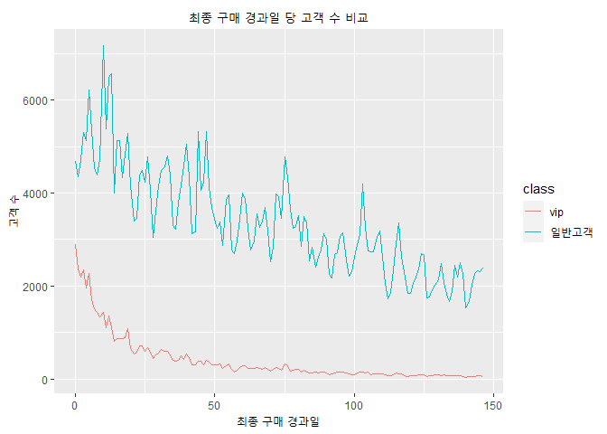

```r
diff_finalterm<-diff %>% group_by(class, finalterm) %>% summarise(n=n())

ggplot(data=diff_finalterm, aes(x=finalterm, y=n, color=class)) +
  geom_line() +
  ggtitle('최종 구매 경과일 당 고객 수 비교') +
  xlab('최종 구매 경과일') +
  ylab('고객 수')+
  theme(plot.title = element_text(hjust=.5))
```

### 인사이트

- VIP 고객이 일반 고객보다 최종 구매 경과일이 증가할 수록 해당하는 고객 수가 급격하게 떨어진다.
- 이는 VIP 고객의 최종 구매 경과일이 더 짧다는 것을 의미한다.
- 따라서 VIP 고객의 충성도가 더 높다는 것을 알 수 있다.

## 이탈 가능성 비교

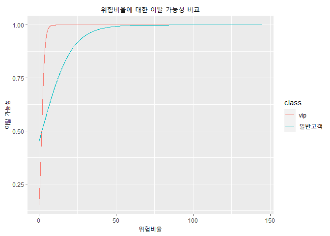

```r
ggplot(data=diff, aes(x=riskratio, y=y, color=class)) +
  geom_line() +
  ggtitle('위험비율에 대한 이탈 가능성 비교') +
  xlab('위험비율') +
  ylab('이탈 가능성') +
  theme(plot.title = element_text(hjust=.5))
```

### 인사이트

- VIP고객들의 경우 약간만 오래 접속을 하지 않아도 이탈할 가능성이 높아진다.
- 이탈 곡선이 완벽한 S자를 그리면서 오른쪽으로 치우칠수록 긍정적이라고 볼 수 있다.
- 따라서 일반고객의 경우 VIP 고객보다 평균 접속 주기보다 더 오랜 기간 접속하지 않더라도 재접속하는 고객이 많다는 의미이다.
- 위험비율이 0일 때, 즉 조사 당일 날 구매를 한 고객이더라도 일반 고객의 이탈 가능성이 VIP 고객보다 더 크다.